# QuARG - Quality Assurance Report Generator

Laura Keyson, EarthScope Consortium

#### Questions or comments can be directed to the EarthScope Quality Assurance Group at qa-qc@earthscope.org.

QuARG is a Python client that allows network operators to generate quality assurance (QA) reports from start to finish. These reports utilize EarthScope's database of [MUSTANG](https://service.earthscope.org/mustang/) data quality metrics to find and highlight potential issues in the data, reducing the amount of time that analysts need to spend scanning the data for problems.

Users have the ability to customize QuARG to adapt to their particular network. Some features that can be personalized:

- Add, edit, or remove Thresholds based on what best fits the network instrumentation.
- Group instrumentation by Network, Station, Locations, or Channels, defining thresholds individually for each group.
- Use metric values sourced from either EarthScope or a local ISPAQ database. Similarly, locally-sourced or EarthScope-provided metadata.
- Create preference files to minimize the number of fields that users need to input, easily track what thresholds were used to find issues, and potentially create a series of files to be utilized for different use-cases within a network.
- Use the built-in ticketing system or an external one, whichever works better for your workflow.

This utility guides users through the process of generating a list of potential issues, examining and tracking issues, and generating a report.

The final report looks something like this, though yours will likely be more thorough and can include images and links in the description:

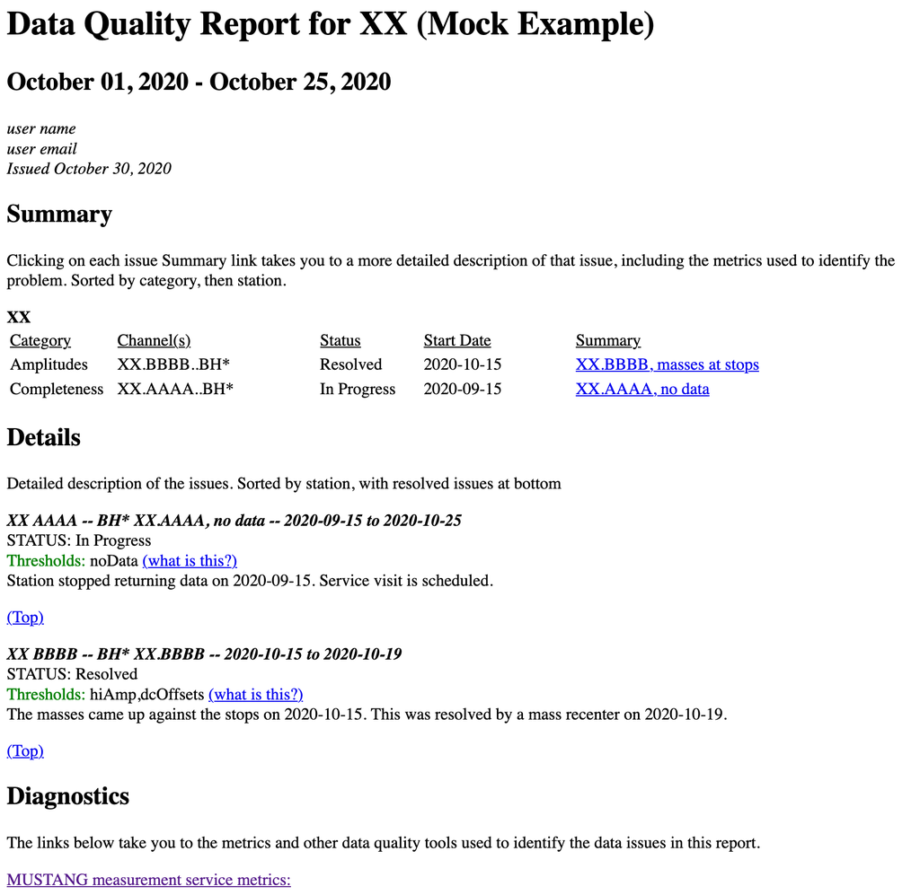

QuARG can be installed on Linux and macOS.

### Table of Contents

| Main Section | Sub Sections |
| --- | --- |
| Background | Definitions |
| Installation | Download the Source Code Install the Anaconda Environment Creating the quarg environment for macOS or Linux |
| Overview |  |
| Using QuARG | Find Issues Preference File Thresholds File Examine Issues Create Ticket View Tickets Update Tickets Generate Report |
| Files | Issue File Ticket File Final Report Transient Files |
| Appendix | Default Thresholds |

# Background

Back to Table of Contents

[EarthScope](https://www.earthscope.org/) (formerly IRIS) Data Services has been performing quality assurance checks on data since the Transportable Array began in 2004. Since that time, we have expanded and improved our quality assurance efforts, including developing a comprehensive quality assurance system called MUSTANG with over 40 metrics available through our [webservices](https://service.earthscope.org/mustang/).

In addition to the weekly QA performed on the TA network, we developed monthly quality assurance reports for the _GSN virtual network. Since then, we added a few more networks to our monthly and quarterly network reports as we refined our methods and improved the QuARG utility. We wrapped up our final network report in Summer 2019 with the goal of providing the QuARG utility to individual networks for the purpose of performing their own QA. While this tool was born at the DMC, intended for generating reports on very specific networks and leveraging tools that we have available in Seattle, the utility has since been expanded to be useful to network operators working on their own networks.

Over the years, we have refined the process of generating a report into four primary steps:

- Find potential issues by utilizing MUSTANG metrics
- Examine all potential issues
- Ticket any true problems
- Generate a final report derived from the open or existing tickets

The QuARG utility follows this same workflow to help guide users through the process from start to finish.

### Definitions

Back to Table of Contents

In case you are new to this or need a refresher, here is a review of a few terms:

1. **Metric**  
   “Metric” is a term that is used to describe *some* quality or aspect of the data. This can range from quite simple - say, the number of gaps in a day or the maximum value recorded in a day. It can also be more complex, such as taking the cross correlation of two channels at a station and recording the maximum correlation value. Metrics do not inherently tell us whether the data is “good” or “bad” - they simply tell us *something* about the data. It is up to us, as Network Operators or Researchers, to use those metrics to decide what data is good or and what data bad. And remember, what is “bad” for one purpose may be very “good” for another, and vice versa.  
   For both MUSTANG and ISPAQ, metrics are calculated for each N.S.L.C. target, and generally are calculated on a per-day basis. There are a few exceptions, such as the metrics that are based on the data from a window surrounding the start time of an earthquake.  
   The usage of the term “Metric” can get complicated and confusing. Generally, the term refers to a *concept* or *algorithm*, such as the metric “num_gaps”. A *value* is calculated for each metric-target-day. We tend to call these values “value” or “measurement”, hence accessing them via our measurements webservice. So IU.ANMO.01.BHZ has a sample_median value of 6241 counts for 2020-01-01 - here, the “metric” is sample_median and the “value” (or measurement) is 6241.  
   It is suggested that you familiarize yourself with the metrics that MUSTANG uses. A full list with a brief description can be found [here](https://service.earthscope.org/mustang/measurements/1/) - click on the red `Current list of all metrics` button to pull down the full list. Clicking on the `Detailed Documentation` button for any given metric will take you to a page that describes it more fully.
2. **Threshold**  
   Thresholds take a metric from a simple *description of the data* and moves it into a way to *determine if the data is “good”*. We use the term Threshold to mean a `Metric` plut a `Cutoff Value`… or, in many cases, a combination of metrics and cutoff values. For QuARG, we actually focus on the data that is *“bad”*, since Network Operators need to know where things are going wrong so that they can fix it.  
   One thing to keep in mind is that different instrument types - broadband, short period, strong motion, etc - may have different cutoff values. For example, strong motion instruments have a very different noise profile than broadband instruments, and even a healthy strong motion instrument will have a significant portion of the noise profile that is above the New High Noise Model (Peterson, J, 1993, Observations and Modeling of Seismic Background Noise, U.S.G.S. OFR-93-322) . So thresholds using [pct_above_nhnm](https://service.earthscope.org/mustang/metrics/docs/1/desc/pct_above_nhnm/) probably ought to have different cutoff values if applied to strong motion and broadband.  
   It should be noted that in QuARG, some Thresholds are based on metadata as well. This can help you find cases where the metadata may be incorrect or incomplete.  
   Here are some examples of thresholds:  
   pct_above_nhnm > 90 && dead_channel_lin > 2  
   Dip != 0 [for horizontal channels]  
   num_spikes >= 500  
   percent_availability = 0  
   num_gaps / percent_availability >= 12  
   [average] num_gaps > 2  
   You will notice that there are a variety of types of thresholds in those examples: there are simple cases in the form of *METRIC* [operator] *VALUE.* There are also *METRIC1* / *METRIC2* [operator] *VALUE*. There are also thresholds that that an *AVERAGE* of a *METRIC* over the reporting period and compare that to a *VALUE.* There are some thresholds that apply only to certain subsets, such as only to the Horizontal or only to the Vertical channels. There are many possible ways to define a Threshold, and the `Threshold Definitions Form` allows you to do all of these types of comparisons, plus a couple more. This may make the thresholds a little more complicated, but we think that it is worth it to have greater flexibility for you, the user.  
   IMPORTANT NOTE: The Thresholds, and particularly the cutoff values, that come with QuARG are ones that we have found *empirically* to balance between false positives and false negatives. They are not set in stone, and will very likely benefit from refinement based on your own network. We have made it so that you can edit, add, or remove thresholds based on your own needs.
3. **MUSTANG**  
   MUSTANG is the Quality Assurance system that we have built at EarthScope. It is essentially an entire workflow that ingests data from our archives and outputs a range of about 45 metrics. When data comes into EarthScope, whether in realtime or latent, it triggers a series of steps that lead to metric calculation on that data. The UTC day after data is archived, MUSTANG will begin calculating metrics on the data. Note that archiving can be up to about a day after realtime data streams in, due to the way that the data is pooled prior to archiving.  
   We store the metrics we have calculated in a series of databases that are accessible to users through our [web services](https://service.earthscope.org/mustang/). Most of the metrics are accessed through the [measurements service](https://service.earthscope.org/mustang/measurements/1/), though there are also a handful of other services that are primarily related to PSDs and PDFs.  
   If you are unfamiliar with our web services, in simple terms it is a way to input a specific URL into your webbrowser and have the requested metric values returned to you. Or, you can use your favorite language (python in the case of QuARG) to do the work for you.
4. **ISPAQ**  
   Because MUSTANG is inherently built to work with the EarthScope data archive, and we know that not all data streams into our archive, we have created a portable version of MUSTANG that users can install on their own computer to run metrics on their local data. This utility, [ISPAQ](https://github.com/EarthScope/ispaq), is a command line python tool that can write metrics to a file system or to a sqlite database (in ISPAQ 3.0, to be released soon). Those ISPAQ metrics that are written to a sqlite database can be accessed by QuARG by specifying the `Metric Source` from within the `Preference File Form`. This allows greater flexibility - networks can still use QuARG to find issues in their network even if the data does not get archived at EarthScope and we do not have MUSTANG metrics for that data.

Back to Table of Contents

# Installation

Back to Table of Contents

QuARG is distributed through *GitHub*, via EarthScope’s public repository (*EarthScope*). You will use a `git` client command to get a copy of the latest stable release. In addition, you will use the `miniconda` python package manager to create a customized Python environment designed to run QuARG properly.

If running macOS, Xcode command line tools should be installed. Check for existence and install if missing:

```
xcode-select --install
```

Follow the steps below to begin running QuARG.

### Download the Source Code

Back to Table of Contents

You must first have `git` installed your system. This is a commonly used source code management system and serves well as a mode of software distribution as it is easy to capture updates. See the [Git Home Page](https://git-scm.com/) to begin installation of git before proceeding further.

After you have git installed, you will download the QuARG distribution into a directory of your choosing from GitHub by opening a text terminal and typing:

```
git clone https://github.com/EarthScope/quarg.git
```

This will produce a copy of this code distribution in the directory you have chosen. When new quarg versions become available, you can update QuARG by typing:

```
cd quarg
git pull origin main
```

### Install the Anaconda Environment

Back to Table of Contents

[Anaconda](https://www.anaconda.com) is quickly becoming the *defacto* package manager for scientific applications written python or R. [Miniconda](http://conda.pydata.org/miniconda.html) is a trimmed down version of Anaconda that contains the bare necessities without loading a large list of data science packages up front. With miniconda, you can set up a custom python environment with just the packages you need to run QuARG.

Proceed to the [Miniconda](http://conda.pydata.org/miniconda.html) web site to find the installer for your operating system before proceeding with the instructions below. If you can run `conda` from the command line, then you know you have it successfully installed.

By setting up a [conda virtual environment](https://conda.io/projects/conda/en/latest/user-guide/concepts.html#conda-environments), we assure that our QuARG installation is entirely separate from any other installed software.

### Creating the quarg environment for macOS or Linux

Back to Table of Contents

You will go into the quarg directory that you created with git, update miniconda, then create an environment specially for quarg. You have to `activate` the QuARG environment whenever you perform installs, updates, or run QuARG.

```
cd quarg
conda update conda
conda create --name quarg -c conda-forge --file quarg-conda-install.txt
conda activate quarg
```

See what is installed in our (quarg) environment with:

```
conda list
```

Every time you use QuARG, make sure that you `conda activate quarg` to ensure that it will run smoothly.

To run QuARG, simply activate the conda environment and run it as a python script:

```
(quarg) bash-3.2$ python QuARG.py
```

Especially on Linux machines, if QuARG still isn’t working, make sure you have the OpenGL and mesa-dri libraries installed.

# Overview of the QuARG Workflow

If it hasn’t been emphasized enough yet, QuARG facilitates a workflow through which an analyst creates a final report.

Within QuARG, there are a number of working parts that interact with each other to move the user through this process. The goal of this section is to provide an overview of how each of those cogs interact with each other within the larger machine, so that you might have a better understanding of which processes and files rely on each other.

Elsewhere in the documentation, we spend considerable time detailing each of the processes and how to use them. Here, we gloss over the specifics and simply introduce the parts to you.

#### Broadest View

QuARG is a program to walk you through the four steps of report generation (Finding Issues, Examining Issues, Creating Tickets, Generating Report), and each of those four steps interacts in some way with a file (or files) external to the program. These files are created, edited, used, and passed along to the next step in one way or another as the analysts transforms a list of potential issues into a definitive Quality Assurance Report.

In the figure below, the top bar represents four of QuARG’s tabs. The row just below that are sub-processes that can happen in some tabs, while the bottom row represents some of the most important files that QuARG generates (ie, not the temporary files that are created and destroyed). The arrows indicate whether the QuARG process writes to or reads from the external file.

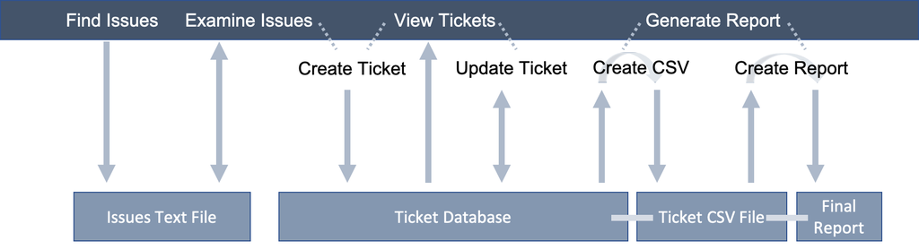

#### Find Issues

The first step of the process is relatively simple in concept, though more complex in execution: Find Issues calls on an external python script (findIssues.py), which in turn calls on a couple other scripts. Because it calls on these external files, you could hypothetically run findIssues.py completely outside of QuARG (the command to do this is spit out on the command line when the Find Issues button is pushed), though that isn’t particularly recommended. Find Issues will load metrics from either the MUSTANG web services or a local ISPAQ database, crunch values based on the defined thresholds, and output a list of potential issues to a text file.

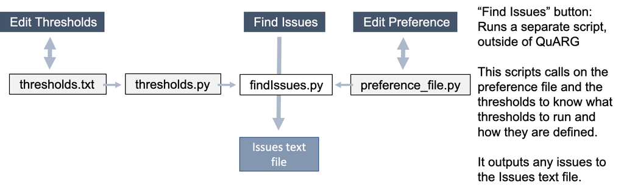

To edit the Preference file (preference_file.py), you use the Edit Preference form - this will read from the existing preference file (if there is one) and write out to a new or existing file when you hit `Save Preference File`. Similarly, use Edit Thresholds to edit the thresholds.txt file. This will read from the existing file and write any changes to it when `Save Thresholds` is pushed.

#### Examine Issues

Examining issues is one of the most straightforward processes - it reads in the file that Find Issues just created, saves it in QuARG’s memory (which is where all of the changes are stored when you mark the status, add notes, etc), and writes back out to the file when you hit the `Save` button.

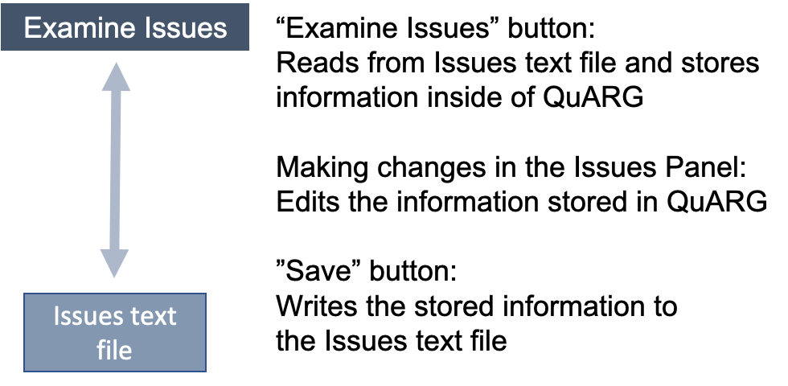

Note that Examine Issues reads from and writes to the Issue File. As you work through the list of issues, marking their status (To-Do, New, Existing, False Positive, etc) or adding notes to help you track your progress and understanding, the progress that you save is being written to the Issue File. This is all done to help you keep track of your work, but anything added here will not be included in the final report. It is a separate process to create a ticket, and tickets are the basis fo the final report.

#### Create Ticket

Creating a ticket is the only way to bridge between the list of issues (created during Find Issues) and the final report. In many ways, the issues list and the tickets are de-coupled from one another - hypothetically, they could be completely unrelated to one another, though that wouldn’t make much sense to do. You can make a ticket for all or none of issues from the issues list. You can create tickets for problems that you’ve found that weren’t on the issue list. Find Issues will present to you potential problems, and you can make all sorts of notes in the Examine Issues pane, and save those notes to the Issue File - but none of that information will be passed into the final report until you make a ticket describing the problem.

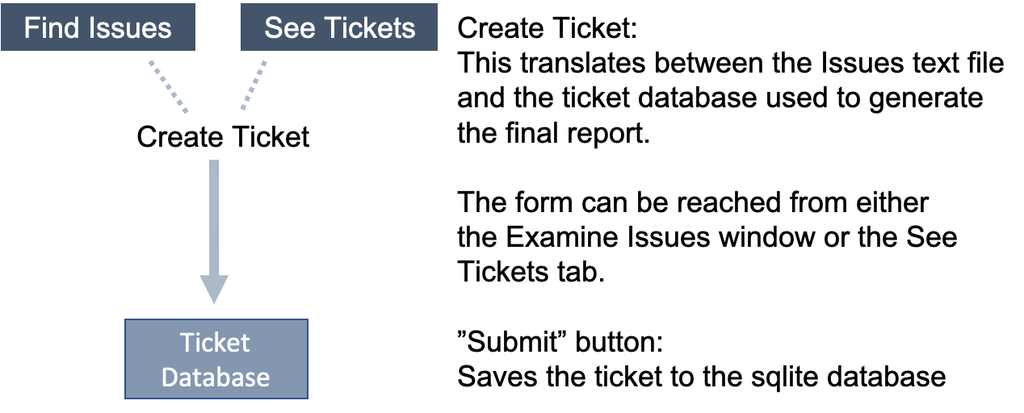

The Create Ticket form can be found from either the Examine Issues Pane, or from the View Tickets Tab. When you fill out the form and `Submit` the ticket, it is then added to the db/quargTickets.db database.

#### See Tickets

Once there are tickets in the database, they can be retrieved and viewed using the See Tickets button in the View Tickets Tab.

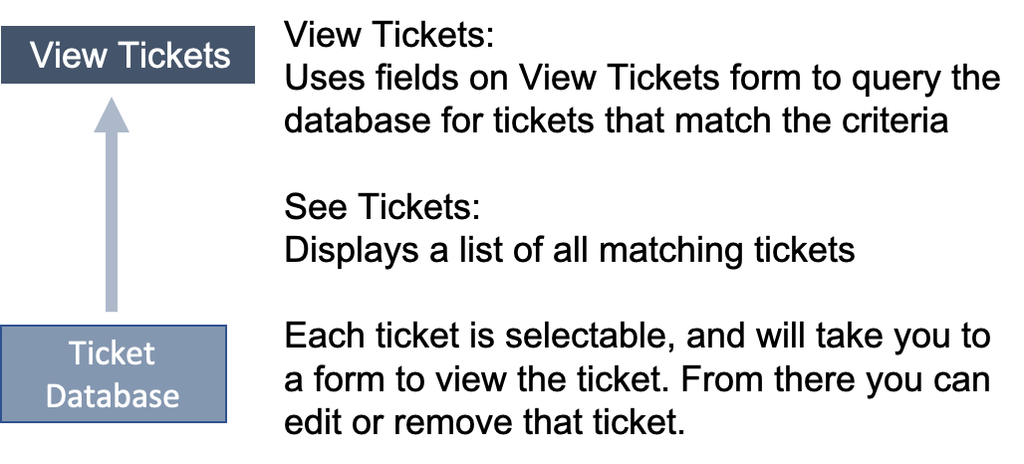

#### Update Ticket

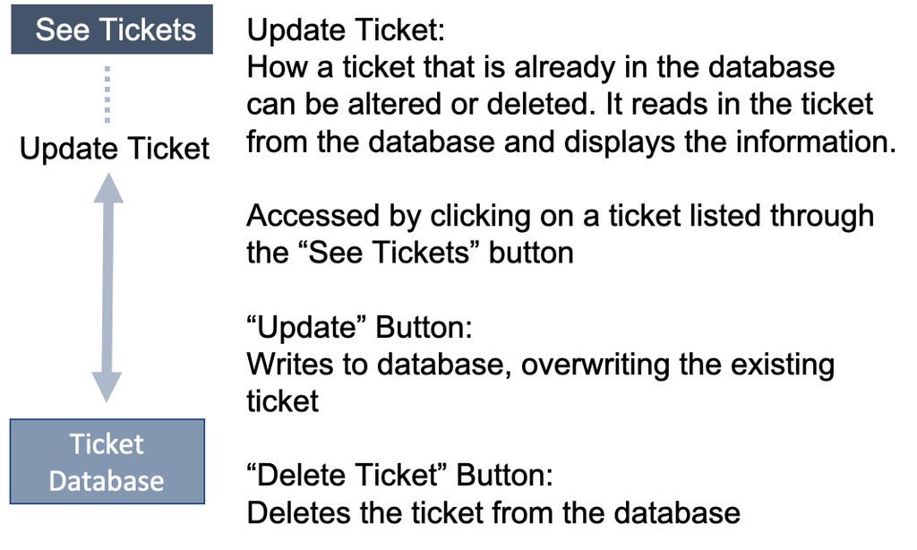

#### Generate Report

This section has the most moving parts working in conjunction to convert the tickets in the database into a final report.

If `Use QuARG Tickets for Report` is selected, then it will first translate the tickets in the database into a csv text file. If that button is not selected, then the csv file will not be created and it will need to be supplied by the user - this is so that users who use an external ticketing system can continue to use that other system, and they just need to export their desired tickets into a csv file of the correct format. More information on the details of the file are in the `Ticket File` section.

With the CSV file in place, QuARG then translates that file into the final report in .html format.

This means that a) if you change a ticket without regenerating the CSV File, then those changes will not be reflected in the final report. b) changes made to the CSV file do not affect the tickets in the database.

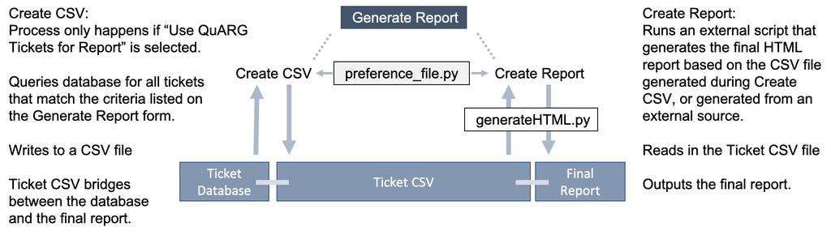

Now that you have a very broad understanding of how QuARG works, the following delves into much greater detail about every step of the process.

# Using QuARG

Back to Table of Contents

Every time you use QuARG you must ensure that you are running in the proper Anaconda environment. If you followed the instructions above you only need to type:

```
cd quarg
conda activate quarg
```

after which your prompt should begin with `(quarg)`. To run QuARG, you use the `QuARG.py` python script that lives in the quarg directory. The example below shows how to get the QuARG GUI to start up. A leading `./` is used to indicate that the script is in the current directory.

```
(quarg) bash-3.2$ ./QuARG.py
```

or

```
(quarg) bash-3.2$ python QuARG.py
```

When you open the utility, you will see something that looks like this:

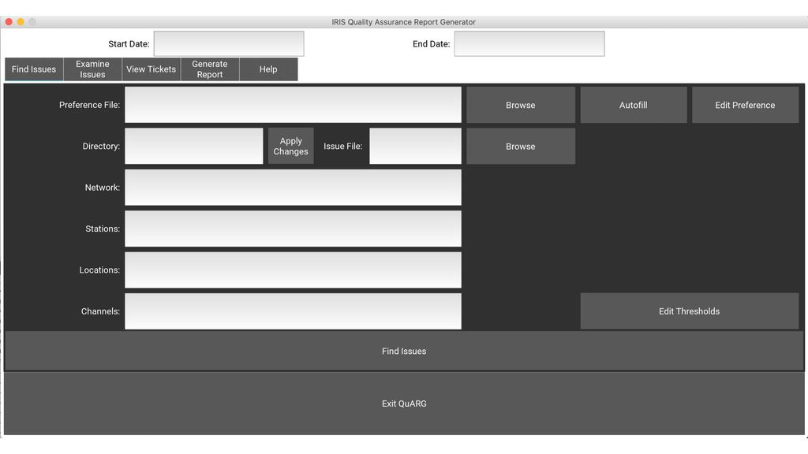

There are four tabs across the top and each tab is used for a specific part of the report process:

- Find potential issues using MUSTANG metrics
- Examine all potential issues
- Ticket any true problems
- Generate a report

**Find Issues** is where you will generate a list of potential issues by combining MUSTANG metrics (Threholds) together. From this tab, you can access two other important pages:

- Preference File Form - how you edit the Preference File
- Threshold Definitions Form - where you edit the Thresholds used to `Find Issues`

**Examine Issues** provides tools for processing the list of potential issues and diagnosing possible causes. You can also create tickets here.

**View Tickets** is where you can create, view, edit, and delete tickets.

**Generate Report** uses the tickets that a user specifies to generate a network report.

Within each tab there are a number of fields, most of them are common to all tabs.

First is the **Preference File** - this is the location where the program will find the preference file on the filesystem. You can type the pathway manually, or use the `Browse` button next to the Preference File field to navigate to and select the file. An example file preference_file_EarthScope.py is provided in the base quarg directory, so when you use the `Browse` button you should find that file along with all of the other QuARG-related files.

Next to the `Browse` button is an `Autofill` button - once a file has been selected and the path is displayed in the Preference File field, this button will load the preference file and fill in the other fields. When this is done within one tab (say, Find Issues) it will also fill in the fields of another tab (Examine Issues, View Tickets, and Generate Report). More detail about the Preference File later.

If you do not want to use the values from the preference file, you can either opt to not use Autofill, or you can simply change the values in the fields you would like to change after you have Autofilled from the preference file. Any value that you input into one of the fields will overwrite the corresponding value from the preference file. If you change the `Directory` field, then you will likely want the new directory to be used in all parts of QuARG. To propagate that change through to the other tabs, use the `Apply Changes` button - after this is done, the new directory should be listed in all of the tabs that have the field.

At the bottom of each screen is a large `Exit` button. There is an exit button somewhere along the bottom of every screen in QuARG, and when pushed it will prompt a popup asking if you really want to exit the program. In addition to this `Exit` button, there are many screens that will also have a `Return` button, which will return you to the previous screen. All other buttons will be described in their corresponding sections below.

## Find Issues Tab

Back to Table of Contents

This is where you specify the targets and time range you are interested in for the report, which QuARG then uses to generate a list of potential issues.

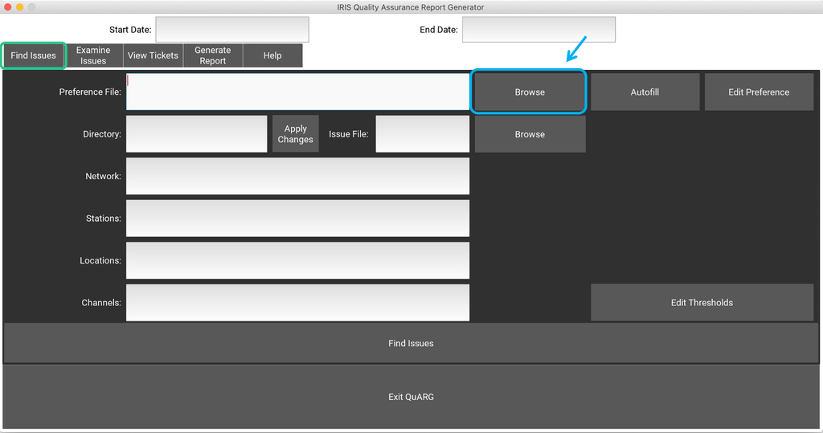

Find Issues is where you will generate a list of potential issues by combining MUSTANG metric values (threholds) together.

There are 8 fields that need to be filled in for this section. As described previously, you can use your preference file to fill in the 7 remaining fields. The easiest way to do this is to use the `Browse` button, navigate to the appropriate preference file, load it, and then use the `Autofill` button to fill in that `Start Date`, `End Date`, `Issue File`, `Network`, `Stations`, `Locations`, and `Channels`.

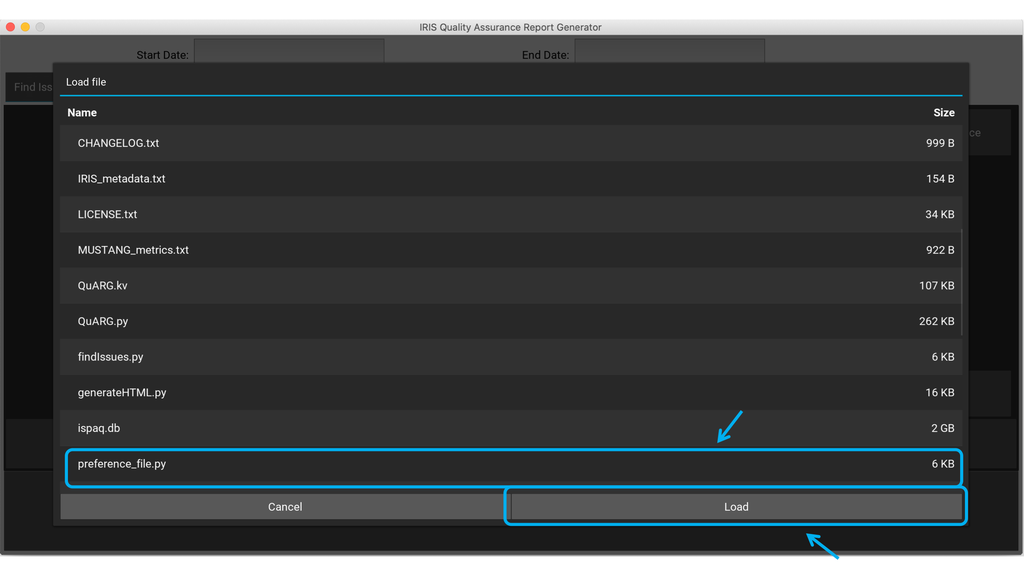

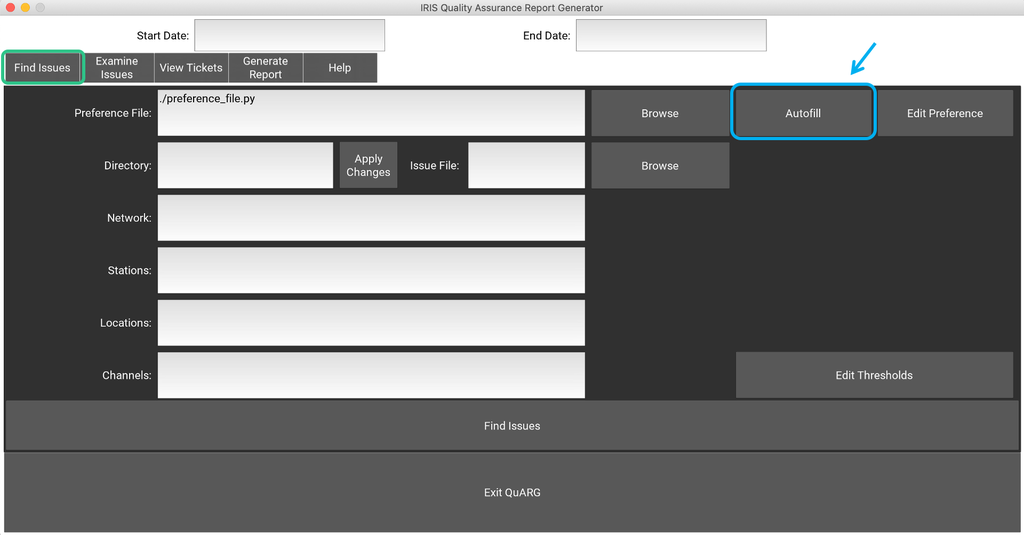

When all fields are filled, the Find Issues button will begin the process of grabbing MUSTANG metrics, combining them based on the defined thresholds, and write all potential issues to a text file (described earlier). If there happens to already be an file of the same name, the utility will ask if you want to overwrite the previous version or cancel the action.

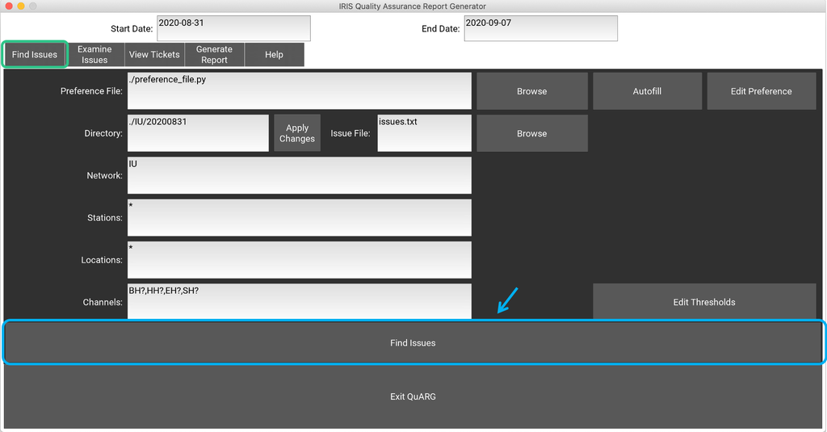

To actually perform this task, the python script findIssues.py is used. This script also relies on thresholds.py and reportUtils.py. Each of these will be described in more detail later.

### Preference File Editor

Back to Table of Contents

The preference file is a place to define values that will be used for reports each time a report is generated. This is to reduce the amount that the analyst needs to input each time, since they can set up a preference file once and use that for each subsequent report.

To edit the preference file, use the `Edit Preferences` button on the `Find Issues` tab of QuARG. That button will take you to a form that allows you to create or edit your preference file(s).

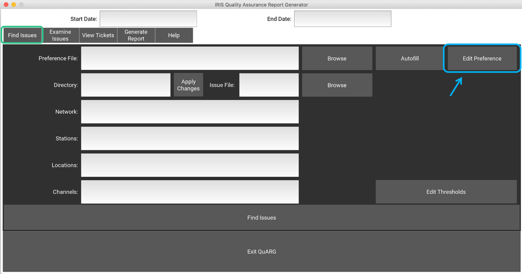

#### Overview

In general, the preference file is broken into a handful of broad categories:

- Target (N.S.L.C.) information
- Report frequency
- Thresholds
- Directories and filenames
- Report header information

Each of these are fields that can and should be adapted for your particular network and report process. *Note*: If you have already loaded a Preference File on the Main Screen, then that file will automatically populate all of the fields in this form.

Very quickly, here is a table with all of the fields in the preference file:

| Directories and Files | Targets | Thresholds | Header | Frequency |
| --- | --- | --- | --- | --- |
| Filename | Network(s) | Threshold Groups | Author | Report Frequency |
| Working Directory | Stations(s) | Group-Thresholds | Project Name |  |
| Issues File | Location(s) |  | Email |  |
| Ticket File | Channel(s) |  |  |  |
| Metric Source | H, V |  |  |  |
| Metadata Source | Instrument Groups |  |  |  |

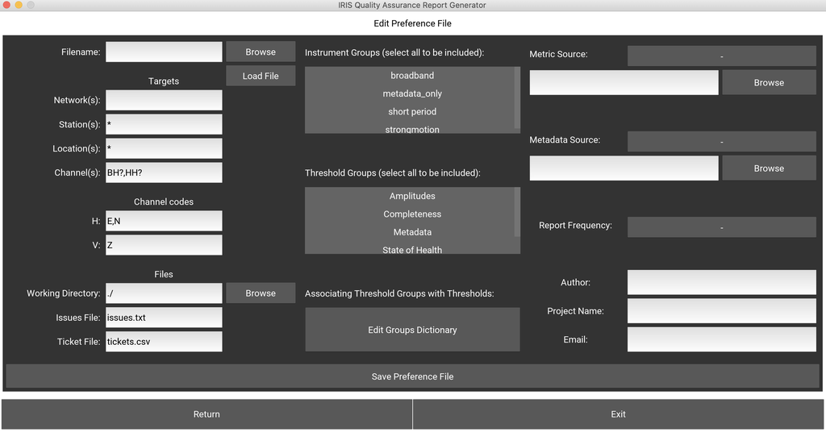

Below is a description of each of the fields.

#### Directories and Filenames

There are a handful of directories and filenames that you can choose to edit. These come with some default values that will work fine for most users, but there may be a case where you want to change the name of some of the files that will be produced throughout the entire report generation process.

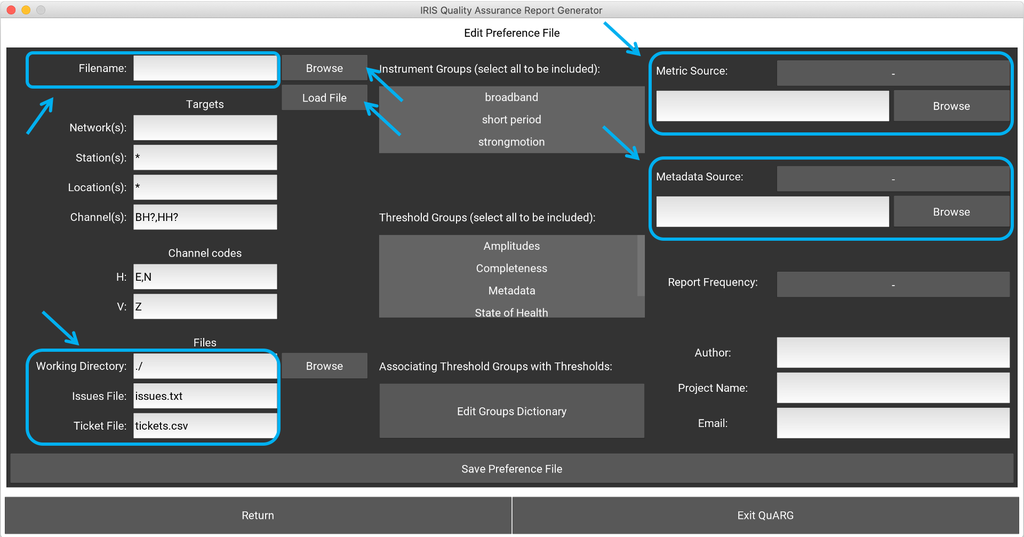

[output not shown]

#### Targets

This section defines which targets (network, station, channel, location) will be used when retrieving quality assurance (likely from MUSTANG, but could also be [ISPAQ](https://github.com/EarthScope/ispaq)) metrics and metadata, and therefore which channels will be included in the issue list. It also defines the category of instrumentation used in the report.

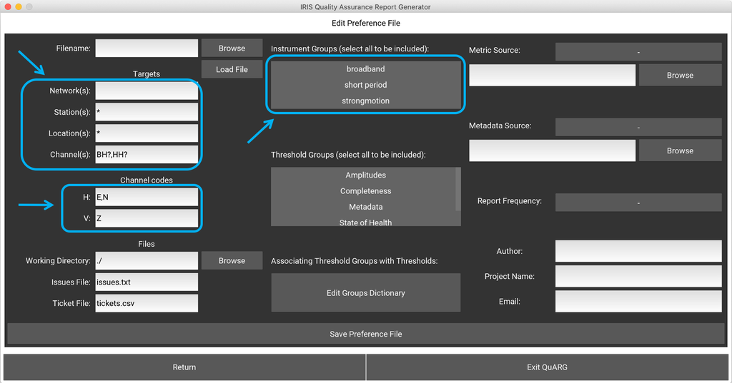

As one of the first steps in the reporting process, QuARG uses the targets listed in the Preference File to go out to the MUSTANG web services (or ISPAQ) and gather all potentially useful metric values. This means that if the fields defined here are very broad, QuARG may try to retrieve a significant volume of metric values and potentially take a long time. After all measurements have been gathered up, then QuARG will subsequently use the targets defined in each of the selected Instrument Groups (see below) to find issues using the defined Thresholds. This means that there are two potential limiting factors affecting the targets to be used in a report: 1) Those allowed by the Preference File’s Network, Station, Location, and Channel fields, and 2) those allowed by the Instrument Groups Network, Station, Location, and Channel Fields. While there is no right or wrong way to do the target filtering, one way that is suggested is to leave the Instrument Groups more broadly defined and then to be more specific within the Preference File. This way, the exact same Thresholds can be used even if you generate multiple Preference Files that each have different targets, say different network codes or different instrument types depending on your particular needs.

The following fields are fairly self-explanatory. Each of them can contain multiple values as a comma-separated list, and can include wildcards such as "*" or “?”:

- **Network**: Network code(s). Example: `IU`
- **Station**: Station code(s). Example: `*` or `ANMO, ADK`
- **Location**: Location code(s). Example: `*` or `01`
- **Channel**: Channel code(s). Example: `BH?,HH?,EH?,SH?` or `BHZ`

Related are a couple of fields that are used when performing the metric combinations for the thresholds.

- **Channel Codes**: There are two fields here, and they define which codes are associated with the horizontals and vertical channels. For example, if the network contains 3-component stations that are labelled as E,N, and Z then we would defined `H: E,N` and `V: Z`. But if the network uses 1, 2, and 3 then we would define `H: 1,2` and `V: 3` - or whatever your particular network does. These fields are included to allow networks to explicitly define what coordinate system they use in case there is variation. The channels defined here are what will be used when executing thresholds that have specifically dictated that H[orizontal] or V[ertical] channels should be used in that threshold (see `Thresholds Definition Form`)
- **Instrument Groups**: Using the `Threshold Definitions Form` Instrument Group Popup, you can create instrument groupings that makes it easy to tailor threshold definitions depending on the instrument. For example, broadband instruments have a different noise profile (PSDs or PDFs) than short period instruments, and therefore the thresholds relating to the noise levels ought to be different for broadbands and short periods. Using the `Threshold Definitions Form`, you can add or remove as many of these instrument groups as you want. Here in the `Preference File Form` you can select which of those instrument groups you are interested in using to `Find Issues`. To include a group, simply select it from the list. Any that are selected (blue) will be included in the Preference File. For example, you may have threshold definitions for broadband, short period, and strong motion instruments, but perhaps you want to use this preference file for looking at only the short period instruments. You can use this field to dictate that.

#### Thresholds

While the thresholds themselves are defined using the `Thresholds Definition Form`, this is where you get to decide which thresholds should actually be run. There are two ways to do this: 1) by associating Thresholds with certain Threshold Groups (or associating with no Group, which would mean that threshold is not run), or 2) by toggling on or off entire Threshold Groups altogether.

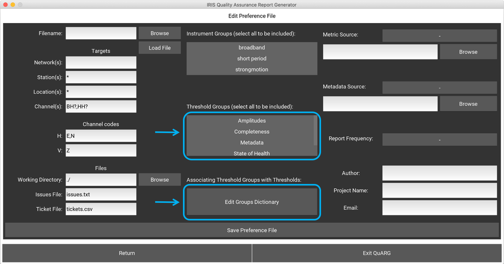

- **Threshold Groups**: QuARG comes with five threshold groups to begin with. These can be though of as general categories: Amplitudes, Completeness, Metadata, State of Health, and Timing. Using the `Thresholds Definition Form`, you can add or remove groups to this list depending on how you see fit for your usage. Here, within the `Preference File Form`, select any or all from the list of available options to determine which groups should be used when finding issues - any selected Threshold Group will be blue, and all that are selected will be included in the Prefrence File. For example, if Metadata is deselected then none of the thresholds associated with Metadata will run.
- **Associating Threshold Groups with Thresholds**: Each of the thresholds can be placed into one of the Threshold Group categories. Once a threshold is assoicated with a Threshold Group, it will run along with all of the other thresholds in that group (given that the Threshold Group is selected, see above). To do this, you must hit the `Edit Groups Dictionary` button that will open a page that has a list of all unused (unassociated) thresholds, all of the Threshold Groups, and a list of all of the associations:

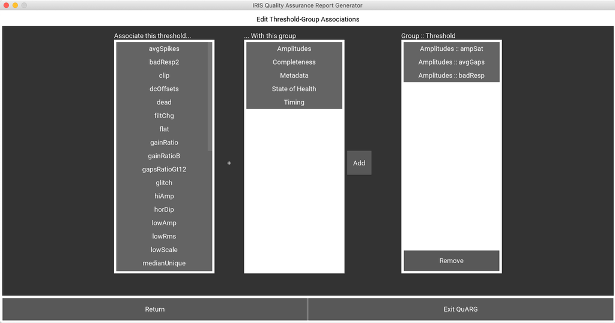

1. *Column 1* - Thresholds  
   The first column here, on the left, contains a selectable list of all Thesholds that have not yet been assigned to a Threshold Group. Since each threshold can only be associated with a single Threshold Group, this list will shrink or grow depending on how you associate Thresholds with Threshold Groups.
2. *Column 2* - Threshold Groups  
   A selectable list of all possible Threshold Groups. This reflects the Threshold Groups that are defined in the Thresholds Form
3. *Column 3* - Associations  
   The third column contains a selectable list of all *Threshold Group::Threshold* associations, ordered alphabetically by Threshold Group, then by Threshold. This column is also dynamic and will grow or shrink depending on what associations you add or remove from the list.

To associate a Threshold with a Threshold Group: simply select one or more thresholds from column one, select the group that they should be associated with, and then hit the `Add` button. When this happens, all selected Thresholds should now show up in the third column and be removed from the first column.

To remove an association: select one or more lines from the third column and hit the `Remove` button. When this happens, any selected rows will be removed from the third column, and those thresholds will now be listed in the first.

**Note**: A threshold can only be associated with one Threshold Group. If a threshold is not associated with any group, it will never be run. This may be something you want to do if, say, your network doesn’t record timing quality in blockette 1001. If that is the case, then the poorTQual threshold will trigger on every single channel for every day – this creates a significant amount of noise to wade through. In that case, I would suggest not associating poorTQual with any Threshold Group, so it is never run.

#### Report Header Information

These fields are used only for the final report header and contain information about who generated the report, the scope of what the report covers, and contact information. Of all of the fields in the preference file these are perhaps the least important, though they must still be filled out.

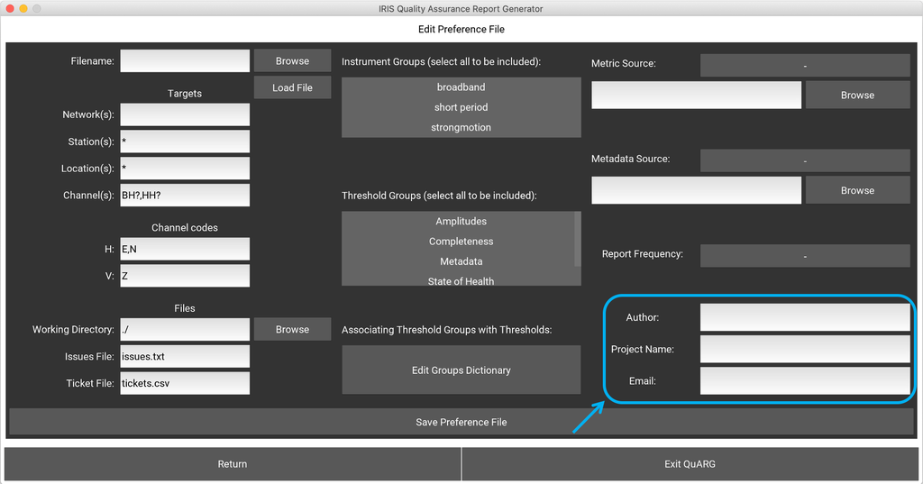

- **Author**: The name of the person that generated the report
- **Project Name**: This is where you can provide some information about what the report covers. For example, if it was for the IU network, the project name could be something like “IU: Global Seismograph Network - IRIS/USGS”. Or if the report covers just the strong motion instruments, it could be something like “IU: Strong Motion”. There is a lot of flexibility here.
- **Email**: The contact email for the person or group that generated the report. This field was created because initailly the EarthScope QA group was generating reports for a select few networks and we wanted to provide our contact information. But it may still be useful for you to include. If not, just put a space in there or something similar.

#### Report Frequency

In the `Preference File Form` there is one field relating to the report frequency: the aptly named `Report Frequency`.

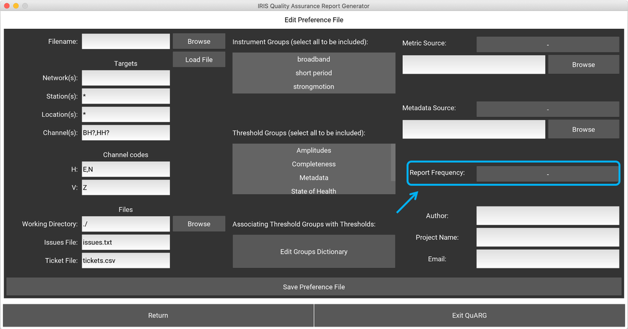

To specify the Report Frequency, select one of the options from the dropdown menu.  
This field is used to do behind the scenes date and directory-naming calculations:

1. First, it will select the *date range associated with the previous period*, which will be used to fill in the `Start Date` and `End Date` fields along the top banner of QuARG.  
   Note: The dates listed in those text boxes are what will be used throughout QuARG (for finding issues, etc) and once loaded from the preference file, those dates can be manipulated within those text boxes. You can change these dates manually, if you wish to cover a different timerange than is autofilled.
2. Second, it will set up the directory structure where all of the intermediate files and the final report will be held, as it creates a new subdirectory for each report. This directory will incorporate the start date of the reporting period so that it is easy to navigate through the reports.  
   Note: If you change the Start and End dates manually (see #1 above) then you may also want to change the name of the directory to match the dates that you are actually using for the report. If you change the name of the directory manually, then you will want to hit the `Apply Changes` button to ensure that new directory is used throughout QuARG.

There are currently four frequency options:

- *Quarterly*: Quarters are defined as: Jan-Feb-Mar, Apr-May-Jun, Jul-Aug-Sep, Oct-Nov-Dec.
  - Dates: So if you run QuARG between April 1st and Jun 30th, 2020, it will autofill the dates as: `Start Date: 2020-01-01` and `End Date: 2020-04-01`.
  - Directory: In addition, it will set up the directory in the form of `Working Directory`/`Network`/YYYYMM/, where YYYYMM are the year and month that begins the previous quarter. Again, if you run QuARG between April 1st and Jun 30th, 2020, YYYYMM will be 202001.
- *Monthly*: Months are defined as the first to last day of a calendar month.
  - Dates: If you run QuARG on May 5th, 2020, it will autofill the dates as: `Start Date: 2020-04-01` and `End Date: 2020-05-01`.
  - Directory: The subdirectory is in the form of `Working Directory`/`Network`/YYYYMM/, so that a report started on May 5, 2020 would create sudirectory of 202004/
- *Weekly*: Weeks are defined as Monday through Sunday.
  - Dates: Whatever day you begin the QuARG report process, the dates will resolve to the Monday of the previous week and the Sunday following that. For example, if run on August 13, 2020 (a Thursday), the dates would be: `Start Date: 2020-08-03` and `End Date: 2020-08-10`.
  - Directory: The directory for Weekly reports is set up like YYYYMMDD. Again, if run on August 13, 2020, the new subdirecotry would be 20200803/.
- *Daily*: Daily will run for just a single day. This option resolves to ‘Two days ago’ to give time for MUSTANG metrics to have calculated after EarthScope recieves the data.
  - Dates: If run on August 13, 2020, the dates will be: `Start Date: 2020-08-11` and `End Date: 2020-08-12`
  - Directory: The subdirectory for daily reports is also formatted as YYYYMMDD. If the report is started on August 13, 2020, the new subdirecotry would be 20200811/.

Remember, both the Start/End dates and the subdirectory can be changed manually. If you change the dates, you may want to change the directory name to match.

**Notes**: Depending on the resources available, and the size of the network, it can be easier to keep up with Monthly or Quarterly reports. For a longer period, any given report will take longer, but we have found one Quarterly report to be less time than 3 Monthly reports. But less frequent reports can mean that issues take longer to be diagnosed and remedied. Therefore, any given network will need to strike a balance to meet its own needs.

Also, given the time required to produce a full report, the daily option is not recommended. If it is used, it may be wise to have a preference file that runs only a small handful of thresholds, for example if it runs only the availability thresholds. Otherwise, it may take too long to produce a daily report.

### Thresholds File Editor

Back to Table of Contents

In many ways, Thresholds are the entire basis of of QuARG and these Quality Assurance (QA) Reports. They are a way to take pre-computed [MUSTANG](https://service.earthscope.org/mustang/measurements/1/) or [ISPAQ](https://github.com/EarthScope/ispaq) metric values and use those metrics as a way to find potential issues in the data. The Thresholds File is what QuARG uses to keep track of Instrument Groups (see `Preference File Form`) and Threshold Groups, as well as actually defining the thresholds. To edit this file, you use the `Threshold Definitions Form`. This file is `thresholds.txt` and is necessary for QuARG to `Find Issues`, which creates the file that is used to `Examine Issues`.

In case you need a refresher, some defintions are listed here

### Threshold Definitions Form

The Threshold Definitions Form is where users can edit threshold definitions. It has all of the tools you will need to add, remove, or edit the Thresholds used in QuARG.

**NOTE: it is very important that you save all changes before hitting the `Return` button and returning to the Main Page**

To access the `Thresholds Definitions Form`, hit the `Edit Thresholds` button from the `Find Issues Tab` of the main page.

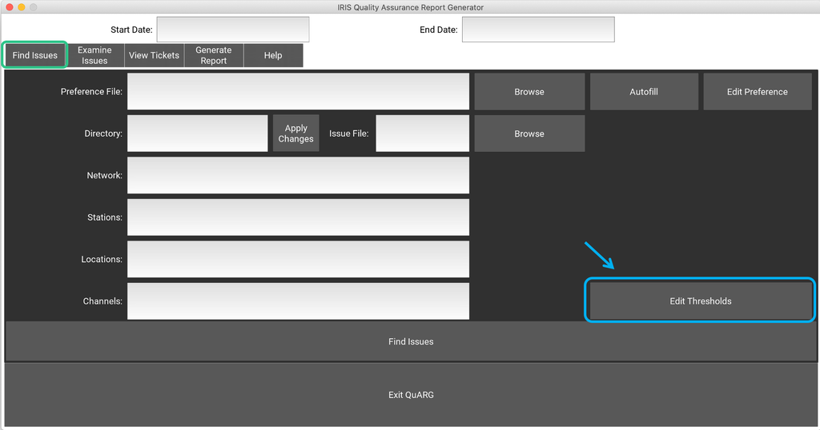

That button will take you to another form where you can add, update, or remove thresholds. Upon entry, you should see:

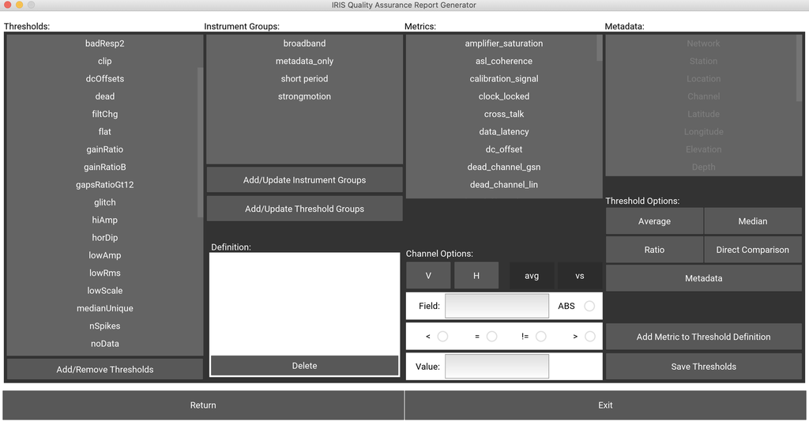

There are two important and interrelated components that need to be defined in this form:

1. The Thresholds: metric and cutoff values, or combinations of metrics and cutoff values.
2. The Instruments: the instrument types, channels, and/or stations that these thresholds apply to.

Because different types of instrumentation can have different qualities about them, often times thresholds that work for one type of instrument wont make sense for another. Because of this, we allow you to create threshold definitions based on instrument group. For example, QuARG comes with a threshold called “flat” - this threshold will look for any cases where *broadbands* have a sample_unique < 200… but since short period instruments tend to have a smaller range, the “flat” threshold will trigger on *short periods* that have sample_unique < 50. If we used the cutoff value of 200 for the short period instruments, then it would trigger on far too many healthy data, leaving the analyst to swim through too many false positives and wasting time.

So, in this form you can create and edit Thresholds (names), and you can also create and edit Instrument Groups. These Thresholds (names) and Instruments Groups can then be associated with each other by setting the *definition* of that Threshold with that Instrument Group. The *definition* is where you choose the *metrics* (or *metadata*) and cut off values that will be used to find problems.

This form has a lot going on, so here is a breakdown:

**1st Column**

- List of Threshold names
- Button to edit Threshold names

In More Detail:  
This column consists entirely of Threshold names. It contains a scrollable, selectable list of *existing* Threshold names. From the example above, you can see the Threshold “flat” on the list. When a `Threshold` is selected, it will turn blue. If you would like to add or remove a Threshold from the list, then at the bottom of the list is a button that says `Add/Remove Thresholds`. Hit that button and it will spark a popup that will allow you to do just that. More on the Thresholds Popup below.

The `Threshold` selected in this column will be used in conjunction with the `Instrument Group` from the 2nd column as you define the Threshold.

**2nd Column**

- List of Instrument Groups
- Button to edit Intrument Groups
- Button to edit Threshold Groups
- Display of Threshold definition
- Button to delete the Threshold definition

In More Detail:  
The 2nd column contains three general parts…

*Instrument Groups*  
At top is a scrollable, selectable list of *existing* Instrument Groups. Instrument groups, which are discussed more here, are used as a way to divide your network into a variety of groups. We have already mentioned the need to divide based on instrumentation type - such as broadband, short period, and strong motion. But there may also be a use in dividing the network spatially, especially if the network spans a wide range of environments. For example, the noise level of a healthy station in a very quiet location would be expected to be quite different than a healthy station in a noisy location, such as on the coast. Using the same threshold for both could potentially A) trigger the healthy, yet noisy, coastal station too frequently, or B) let an actually problem at the quiet site go unseen because the cutoff value is too great. The way that any given Network divides up their instruments will depend strictly on their own needs.

To Add, Remove, or Edit an Instrument Group, then hit the `Add/Update Instrument Groups` Button just below the list and it will produce a popup that will allow you to do that.

*Threshold Groups*  
Below that is the `Add/Update Theshold Groups` button. The Threshold Groups are the same ones that you see in the `Preference File Form` - they are general categories that the Thresholds may fit into. For example, Completeness or Amplitudes. The Preference File will allow you to specify which Thresholds belong in which Threshold Group, so this is simply where you can add or remove a group from the list. When the button is clicked, it will produce a popup that will allow you to do that editing.

*Definition Display*  
At the bottom is an area that will display the definition for the selected Threshold name and Instrument Group. If the white area is blank, then that means either there is no definition provided for that combination of Threshold and Instrument Group, or one (or both) of those fields has not been selected. When there *is* a definition displayed, each part of that definition is selectable - when selected, it will turn blue. This allows you to remove any part of the definition if you would like. To do that, simple hit the `Delete` button below and it will remove all selected parts of the definition.

Due to the flexibility in *types* of definitions (average, ratios, etc), there is some notation used in the display that helps both the user and QuARG know how to interpret that particular definition. Here is a quick summary of what you may see, and what it means:

[output not shown]

**3rd Column**

- List of Metrics
- Channel Options
- Defining the Threshold

In More Detail:

*Metrics*  
At the top is a selectable list of all of the MUSTANG metrics. This list comes from the EarthScope MUSTANG webservices and is refreshed whenever QuARG is connected to the internet so it should stay up to date as we add new metrics. When a metric is selected, it will fill in the text box labeled `Field` below. While you can simply type the metric you are interested in `Field` box directly, the list makes it easy to know what metrics are availble to use.

*Channel Options*  
The channel options allow you to specify whether a threshold, or part of a threshold, should apply to only the horizontal or vertical channels. In most cases, these will not be used since you will want to find issues associated with any and all of the channels. But there are some cases where you would want to limit things. For example, when looking for issues in the metadata you may want to find all cases where the horizontal channels have a Dip != 0. If you applied this threshold to *all* channels, then every vertical channel should get triggered since they ought to have a non-0 Dip. Another example would be rmsRatio, which compares the sample_rms of the vertical channel to and average of the horizontals.

There are 4 buttons for `Channel Options`:

- `V` (verticals)
- `H` (horizontals)
- `avg` (average)
- `vs` (versus)

The latter two can only be used in conjunction with `H`, and can only be used when either `Ratio` or `Direct Comparison` are selected (see below). When selected, the button will turn blue. See table above for more description of “average” and “vs.”

*Defining the Threshold*  
This is where you specify the field, operator, and cutoff value to be used. The `Field` will autofill from either the `Metrics` list or the `Metadata` list when an item from either of those is selected. But what matters is the text listed as the `Field` here, not what item was selected from the list. So you can select, for example, num_gaps from the list, and it will autofill the `Field` with num_gaps, but you can then go change the text to say num_overlaps. num_overlaps would then be the metric used in the threshold definition. Note: if the `Metadata` toggle button is selected (see below) then the `Field` must match an item in the `Metadata` list. If the `Metadata` toggle button is *not* selected, then the `Field` must match an item from the `Metrics` list.

The `ABS` option will specify that this threshold should take the absolute value of the metric before doing the comparison.

Below that are the operator options: `<`, `=`, `!=`, `>`. Greater than or Less than can be used in conjunction with Equal to or Not Equal to.

And finally is the `Value`, which is the cutoff value for the threshold and in most cases must be numeric (the exception is some metadata fields, such as ScaleUnits) .

**4th Column**

- Metadata List
- Threshold Options
- Add Threshold
- Save

In More Detail:

*Metadata List* This is a scrollable, selectable list of all metadata fields that can be used in QuARG. These are based on the EarthScope [station service](https://service.earthscope.org/fdsnws/station/1/) headers at the channel level in the text format. When a field is selected, it will turn blue and will automatically fill in the `Field` in column 3. The metadata list is disabled by default, and only becomes available when the `Metadata` toggle button is selected (see below).

*Threshold Options*  
There are five options available:

[output not shown]

*Add Thresholds* The `Add Metric to Threshold Definition` button allows you to take all of the information you can provided (Field, Operator, Cutoff Value) and add it to the definition of that threshold. In order to do the add, all required fields must be provided (this depends on what type of threshold is being generated, see Complex Thresholds), as well as the Threshold name and Instrument Group both being selectd. When this button is pushed, given all fields are properly supplied, the definition will show up in the `Definition Display`.

*Save*  
**IMPORTANT** To save any and all changes made, you must push the `Save` button. Otherwise, all work will be lost when returning to the Main Page.

#### Complex Thresholds

Two of the threshold types are more complex: Direct Comparison and Ratio. This is because they must involve either two metrics or two channel types. Since you can only input one metric or channel type at once, it is a multi-step process to add these types of thresholds.

##### Direct Comparison

Adding a Direct Comparison threshold requires 3 steps. With the `Direct Comparison` button selected:

- Select the first metric and channel options (if applicable). Hit `Add Metric to Threshold Definition`.
  - This will add the first metric (and channels) to the `Definition Display`, along with " :: compare" at the end.
- Select the second metric and channel options (if applicable). Hit `Add Metric to Threshold Definition`.
  - This will add the second metric (and channels) to the `Definition Display`, along with " :: compare" at the end.
- Deselect any selected metrics, or clear the `Field`, and select the required operator (`>`,`!=`,`=`, or `<`). Hit `Add Metric to Threshold Definition`.
  - This will combine everything into a single line.

Notes:

- This expects two lines with " :: compare" before it will be able to combine them into a single line. If you try to do it prematurely, it will warn you.
- To combine the two existing lines into one, `Field` must be empty. If not, it will warn you.
- To combine the two existing, the operator must be selected. If not, it will warn you.
- It will disregard any value in `Value`
- You can compare the same metric if different channels are selected. Otherwise, you can only compare two different metrics.
- Anywhere above that “metric” was stated could also be “metadata” instead.

##### Ratio

Adding a Ratio threshold requires 3 steps. With the `Ratio` button selected:

- Select the first metric and channel options (if applicable). Hit `Add Metric to Threshold Definition`.
  - This will add the first metric (and channels) to the `Definition Display`, along with " :: ratio" at the end.
- Select the second metric and channel options (if applicable). Hit `Add Metric to Threshold Definition`.
  - - This will add the second metric (and channels) to the `Definition Display`, along with " :: ratio" at the end.
- Deselect any selected metrics, or clear the `Field`, and select the required operator (`>`,`!=`,`=`, or `<`). Provide a numeric cutoff `Value`. Hit `Add Metric to Threshold Definition`.
  - This will combine everything into a single line.

Notes:

- This expects two lines with " :: ratio" before it will be able to combine them into a single line. If you try to do it prematurely, it will warn you.
- To combine the two existing lines into one, `Field` must be empty. If not, it will warn you.
- To combine the two existing lines, `Value` and the operator must be supplied.
- You can compare the same metric if different channels are selected. Otherwise, you can only compare two different metrics.
- Anywhere above that “metric” was stated could also be “metadata” instead.

### Popups

#### Thresholds Popup

When adding or removing a Threshold name from the list, you use the Thresholds Popup, via the `Add/Remove Thresholds` button in the `Threshold Definitions Form`. This looks like:

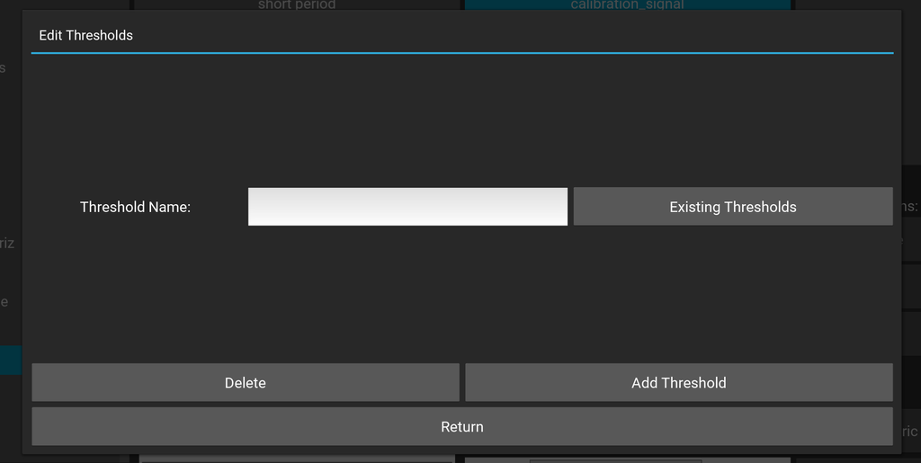

This is where you can add a threshold to or remove a threshold from the list of all thresholds.

**Add Threshold**  
To add a new threshold, simply:

1. Type the new name in the Threshold Name field and
2. Hit the Add Threshold Button.

Now that threshold is available from the list of thresholds (on the left) when you return out of this popup. From there you can select the new Threshold and an Instrument Group, then supply a new definition.

**Remove Threshold**  
To remove an existing threshold:

1. Either type the name into the Threshold Name field, or select the threshold from the dropdown menu under Existing Thresholds. Then,
2. Hit the Delete button to remove that threshold - it will double check that you want to do the removal before it actually removes the threshold.

Note that if you delete a threshold, it also deletes all definitions (for all Instrument Groups) associated with it - so remove with caution. If you no longer want to use a threshold, it *may* be a better move to simply disassociate that threshold from any Threshold Group using the Preference File Editor. That way, the threshold and all definitions will still exist, but that threshold will never run.

Remember: to save changes made here, you must hit the `Save Thresholds` button after returning out of this popup.

#### Instrument Groups Popup

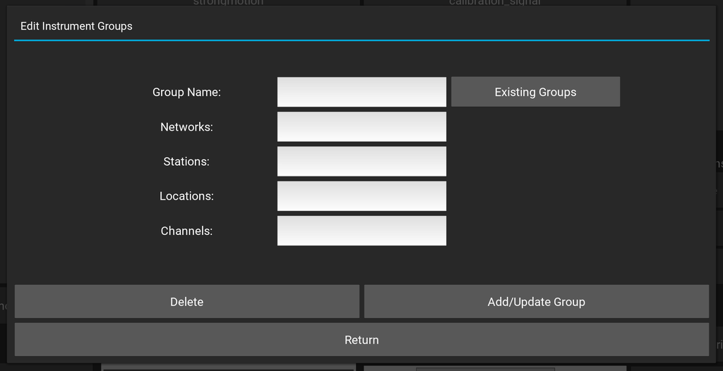

There are a variety of reasons why you may want to have more than one definition for a given Threshold. One reason would be that different types of instruments - for example, strong motion, short period, and broadband - intentionally have different characteristics. These differences manifest themselves in the metric values, and if the same cutoff value is used for different types of instrumentation then it is very likely that either a) issues will be missed in some of your instruments, or b) a lot of false positives will be flagged and overwelm your analyst. Similarly, if your network spans a variety of environments, then you may expect different behaviours based on the location of the station. A station near the ocean will be inherently noisier than one in a very quiet location, and either the thresholds will always flag the noisy stations or the thresholds will miss true issues that might pop up in the generally quiet locations.

To deal with this, we created the concept of an Instrument Group - which is just like it sounds, a group of instruments. Each Instrument Group can have a different definition for a given Threshold, if necessary. Or if the threshold simply doesn’t make sense for a particular instrument group, then it doesn’t have to have a definition associated with it.

This is where you can add, edit, or remove an Instrument Group.

**Add Instrument Group**

1. Type in the new name into the `Group Name` field
2. Fill in the targets that are a part of that group. Each field here can be a comma-separated list, or wildcarded (*,?), and if left blank then it will be wildcarded. This is where you can split the instruments by “environment” (a list of stations) or instrument type (a list of channels).
3. Hit the `Add/Update Group` button.

Note: The targets specified here may be further constrained by the targets specified in the Preference File. For example, if you have an Instrument Group that includes channels “BH?,HH?” but the Preference File says to run only on BH? channels, then only BH? channels will be run.

**Update Instrument Group**

1. Either type in the name of the existing Instrument Group in the `Group Name` field, or select it from the `Existing Groups` dropdown menu
2. Edit the Target fields. If the group was selected from the dropdown menu, then the current values will be filled into the `Networks`, `Stations`, `Locations`, and `Channels` fields and can be changed from there. Otherwise supply the fields as you want them to be.
3. Hit the `Add/Update Group` button

**Remove Instrument Group**

1. Either type in the name of the existing Instrument Group in the `Group Name` field, or select it from the `Existing Groups` dropdown menu
2. Hit the `Delete` button. QuARG will double check that you really want to delete the Instrument Group before deleting it.

Note that if you delete an Instrument Group, it will delete all Threshold defintions associated with it and it will no longer be accessible for the Preference File.

Remember: to save changes made here, you must hit the `Save Thresholds` button after returning out of this screen.

##### Threshold Groups Popup

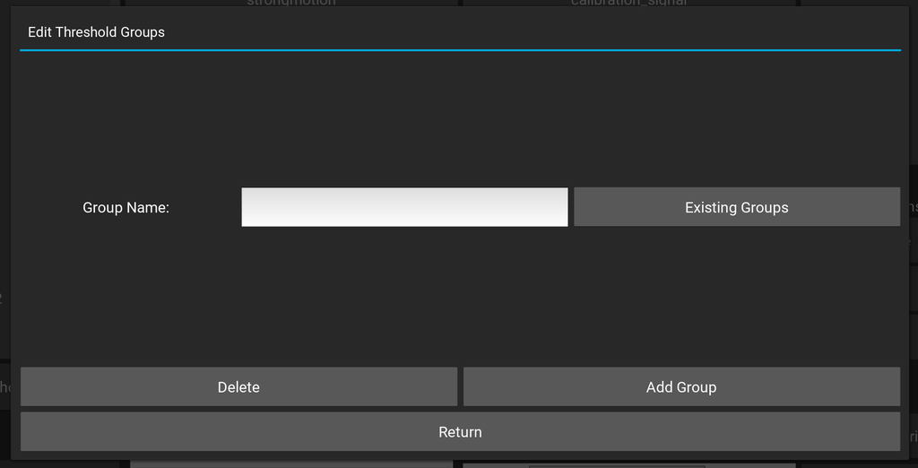

Threshold Groups can be thought of as general categories that the thresholds would fall under. By default, QuARG comes with these Threshold Groups:

- Amplitudes
- Completeness
- Metadata
- State of Health
- Timing

Threshold Groups are used when QuARG executes `Find Issues`. In the Preference File, you can determine which Thresholds are associated with which Threshold Groups, as well as choose which Threshold Groups to run. For each Threshold Group that is selected in the Preference File, all associated thresholds will run.

For example: This means that if “Amplitudes” contains avgSpikes, badResp, dcOffsets, dead, and flat, then all five of those thresholds will run as long as the Preference File indicates that Amplitudes should run. If Amplitudes is deselected in the Preference File, then none of those five thresholds will run.

This popup is where you can choose to add another group to the list, or remove an existing one. If you remove a Threshold Group here, it will still exist in any Preference Files that had been generated prior to the removal. To ensure that the group is truly removed, you will have to edit your Preference File to dissociate any Thresholds from that group. And to run those Thresholds, make sure to associate those Thresholds with another Threshold Group.

**Add Threshold Group**

1. Type the new name in the `Group Name` field
2. Hit the `Add Group` button

**Remove Threshold Group**

1. Either type the name of the group to remove in the `Group Name` field, or select it from the dropdown menu `Existing Groups`
2. Hit the `Delete` button. It will double check that you truly want to delete the Group prior to actually deleting it.

Remember: to save changes made here, you must hit the `Save Thresholds` button after returning out of this screen.

##### Threshold Definitions Popup

There is little description needed for this popup - by clicking on the `View Current Threshold Definitions` it will pop up a more human-readable list of all of the current threshold definitions. This means that you don’t need to click through each Threshold and Instrument Group combination to see what your definitions are. As soon as a change is made, it will be reflected in this popup. But remember: to save the changes for actual use, you must hit the `Save Thresholds` button!

## Examine Issues Tab

Back to Table of Contents

After the Issue File has been generated, using `Find Issues` the next step is to sort through the discovered issues. Many will be true issues, but some will be false positives. It is important to sort through which are actually problematic, and try to determine what the cause might be. This will help in remedying the issue.

The bulk of the time and work that the analyst will spend on a network report will use this part of the program. This is the *very original* purpose of the very first version of QuARG - to keep track of all of the issues found using MUSTANG metrics. This part is where you can thumb through the (potential) issues station-by-station or by threshold. You can mark issues with different statuses to track what will need ticketing, what already has a ticket, and what can be ignored. Write notes about what you’ve found. And use a variety of webservices to help in diagnosing the potential issue.

We have found that it is useful to pull up a list of all open tickets when you start going through the issues for a new report. If the open ticket is still a problem and manifesting itself in the same way, then you can simply mark the issues as Existing and move on, spending less time on it. If it has changed in some way, then that would be good to note in the Ticket. And if the problem has been resolved then the ticket should be updated and closed. It is easiest to do this at the beginning, before adding any new open tickets to the mix. At this point, QuARG does not have the ability to easily display both the Issues Pane and the Ticket List at the same time - perhaps in the future it will be able to - so to facilitate this part of the process, it might be easiest to open two instances of QuARG… one to have a list of existing tickets open, the other to have a list of current issues. This is not ideal, but is certainly easier than flipping back and forth between `See Tickets` and `Examine Issues`.

**Very important** note: any actions you take in the following screen will not affect actual tickets. They are simply for the analyst’s own recordkeeping. Changes will be saved to the `Issue File`. To create, edit, or delete an actual ticket is done in the ticketing screen. **Tickets** are what ultimately go into a report.

### Landing Page

When the user lands on the Examine Issue Tab, it is a very simple interface. Just like The Find Issues Tab, there are fields for Preference File and Issue File. In this case, the Preference File is optional: only the Directory and Filename are required.

If you have already Autofilled from preference file, all fields should already be filled in. Otherwise, you can use the `Browse` button to navigate to the preference file, load it, and `Autofill`. Alternately, you can enter the path to the Issue File directly or use the `Browse` button to navigate to it and load it.

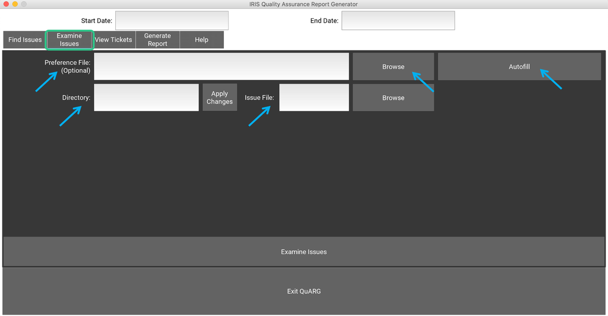

The most important field here is the Issue File - the rest of the Examine Issues capabilities relies on reading in and writing to that file. If the field is not filled in, then there will be a message on the command prompt informing you that it cannot open the (missing) file.

When the Issue File field is properly filled, then use the `Examine Issues` button near the bottom to load up a new screen.

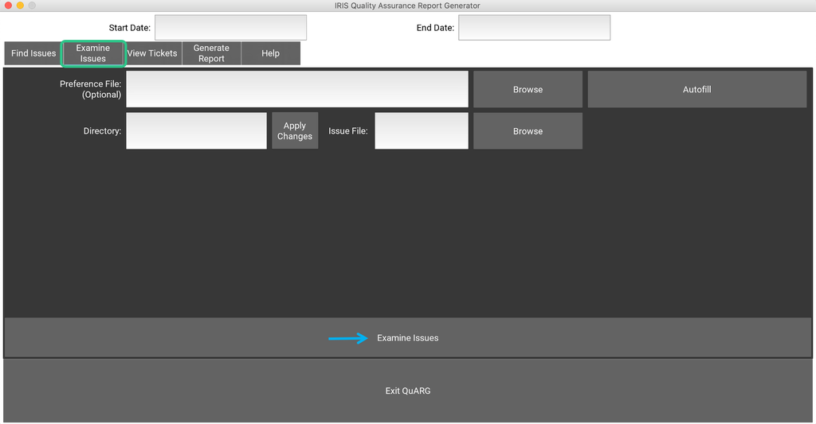

### Examine Issues Screen

When you land on the Examine Issues Screen, it will look something like this (except it probably won’t be empty):

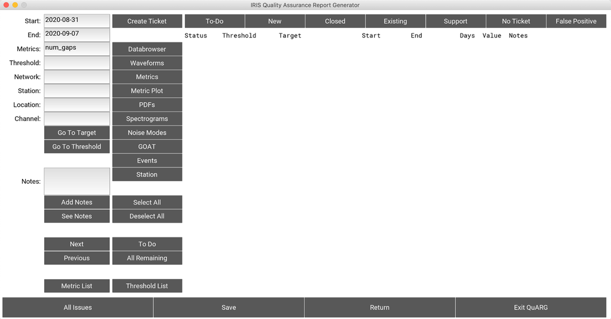

All issues should show up in the Issue Pane when you first enter. If it was unable to load the file for any reason, it’ll give you a warning and produce an empty list. In addition, dates will autofill along the left side, based on the dates loaded from the Preference File (if applicable), and the default metric of num_gaps should show in the Metrics field. As you move through the issues, which are grouped by station, the Station field should update to indicate the current station.

There is a lot going on in this Examine Issues screen, so here we break it down section-by-section:

**Issue Pane**

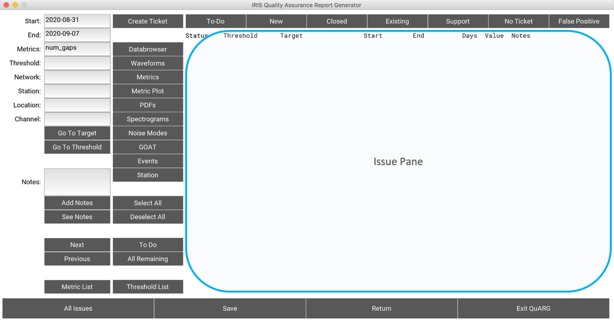

The Issue Pane will display information about the potential issues that were found. It consists of 8 columns:

- *Status* - defaults to TODO when first created, the status can be changed to New, Closed, Existing, Support, No Ticket, or False Positive. This is simply for the sake of the analyst to help track what issues have been examined and the status of those issues, it does not have a direct connection to any potential ticket that is created for the issue.
- *Threshold* - threshold that was triggered
- *Target* - data that triggered the threshold
- *Start* - first of the consecutive days to have the same target-threshold combination
- *End* - last of the consecutive days to have the same target-threshold combination
- *Days* - number of consecutive days
- *Vaue* - if the threshold is an average or median type of threshold, the average or median value is displayed here
- *Notes* - any notes that the analyst might add (using the `Add Notes` button)

Note: There are some thresholds that are an average or median over the entire report period. For these, the Start and End fields will be the start and end of the requested timeframe.

If there are many issues to display, the Issue Pane is scrollable to see all issues. Each row is selectable by clicking on it and multiple rows can be selected at once. To perform many actions, such as `Add Notes` or changing the status, you need to select the row that you wish to affect. More information about actions below.

**Inputs**

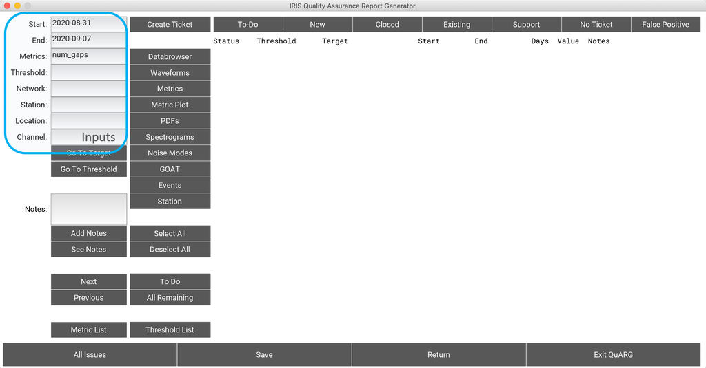

The Inputs section contains fields that the analyst can write in and alter. How exactly these fields are used can vary, but the most common use for them is to be used as inputs into the web services (described in the Diagnosis Tools section below). They are also used in navigating through issues, such as specifying which targets or thresholds you want to view.